# Decision Tree Challenge

Feature Importance and Categorical Variable Encoding

# 🌳 Decision Tree Challenge - Feature Importance and Variable Encoding

## Challenge Overview

**Your Mission:** Create a simple GitHub Pages site that demonstrates how decision trees measure feature importance and analyzes the critical differences between categorical and numerical variable encoding. You’ll answer two key discussion questions by adding narrative to a pre-built analysis and posting those answers to your GitHub Pages site as a rendered HTML document.

**Warning⚠️ AI Partnership Required**

This challenge pushes boundaries intentionally. You’ll tackle problems that normally require weeks of study, but with Cursor AI as your partner (and your brain keeping it honest), you can accomplish more than you thought possible.

**The new reality:** The four stages of competence are Ignorance → Awareness → Learning → Mastery. AI lets us produce Mastery-level work while operating primarily in the Awareness stage. I focus on awareness training, you leverage AI for execution, and together we create outputs that used to require years of dedicated study.

## The Decision Tree Problem 🎯

> “The most important thing in communication is hearing what isn’t said.” - Peter Drucker

**The Core Problem:** Decision trees are often praised for their interpretability and ability to handle both numerical and categorical variables. But what happens when we encode categorical variables as numbers? How does this affect our understanding of feature importance?

**What is Feature Importance?** In decision trees, feature importance measures how much each variable contributes to reducing impurity (or improving prediction accuracy) across all splits in the tree. It’s a key metric for understanding which variables matter most for your predictions.

**Important🎯 The Key Insight: Encoding Matters for Interpretability**

**The problem:** When we encode categorical variables as numerical values (like 1, 2, 3, 4…), decision trees treat them as if they have a meaningful numerical order. This can completely distort our analysis.

**The Real-World Context:** In real estate, we know that neighborhood quality, house style, and other categorical factors are crucial for predicting home prices. But if we encode these as numbers, we might get misleading insights about which features actually matter most.

**The Devastating Reality:** Even sophisticated machine learning models can give us completely wrong insights about feature importance if we don’t properly encode our variables. A categorical variable that should be among the most important might appear irrelevant, while a numerical variable might appear artificially important.

Let’s assume we want to predict house prices and understand which features matter most. The key question is: **How does encoding categorical variables as numbers affect our understanding of feature importance?**

## The Ames Housing Dataset 🏠

We are analyzing the Ames Housing dataset which contains detailed information about residential properties sold in Ames, Iowa from 2006 to 2010. This dataset is perfect for our analysis because it contains a categorical variable (like zip code) and numerical variables (like square footage, year built, number of bedrooms).

## The Problem: ZipCode as Numerical vs Categorical

**Key Question:** What happens when we treat zipCode as a numerical variable in a decision tree? How does this affect feature importance interpretation?

**The Issue:** Zip codes (50010, 50011, 50012, 50013) are categorical variables representing discrete geographic areas, i.e. neighborhoods. When treated as numerical, the tree might split on “zipCode > 50012.5” - which has no meaningful interpretation for house prices. Zip codes are non-ordinal categorical variables meaning they have no inherent order that aids house price prediction (i.e. zip code 99999 is not the priceiest zip code).

## Data Loading and Model Building

### Python

```python
import pandas as pd
import numpy as np
import matplotlib.pyplot as plt
from sklearn.tree import DecisionTreeRegressor, plot_tree
from sklearn.model_selection import train_test_split
from sklearn.metrics import mean_squared_error, r2_score
import warnings
warnings.filterwarnings('ignore')

# Load data
sales_data = pd.read_csv("salesPriceData.csv")

# Prepare model data (treating zipCode as numerical)
model_vars = ['SalePrice', 'LotArea', 'YearBuilt', 'GrLivArea', 'FullBath',
              'HalfBath', 'BedroomAbvGr', 'TotRmsAbvGrd', 'GarageCars', 'zipCode']
model_data = sales_data[model_vars].dropna()

# Split data
X = model_data.drop('SalePrice', axis=1)
y = model_data['SalePrice']
X_train, X_test, y_train, y_test = train_test_split(X, y, test_size=0.2, random_state=123)

# Build decision tree
tree_model = DecisionTreeRegressor(max_depth=3,
                                  min_samples_split=20,
                                  min_samples_leaf=10,
                                  random_state=123)
tree_model.fit(X_train, y_train)

print(f"Model built with {tree_model.get_n_leaves()} terminal nodes")
```

```
Model built with 8 terminal nodes
```

## Tree Visualization

### Python

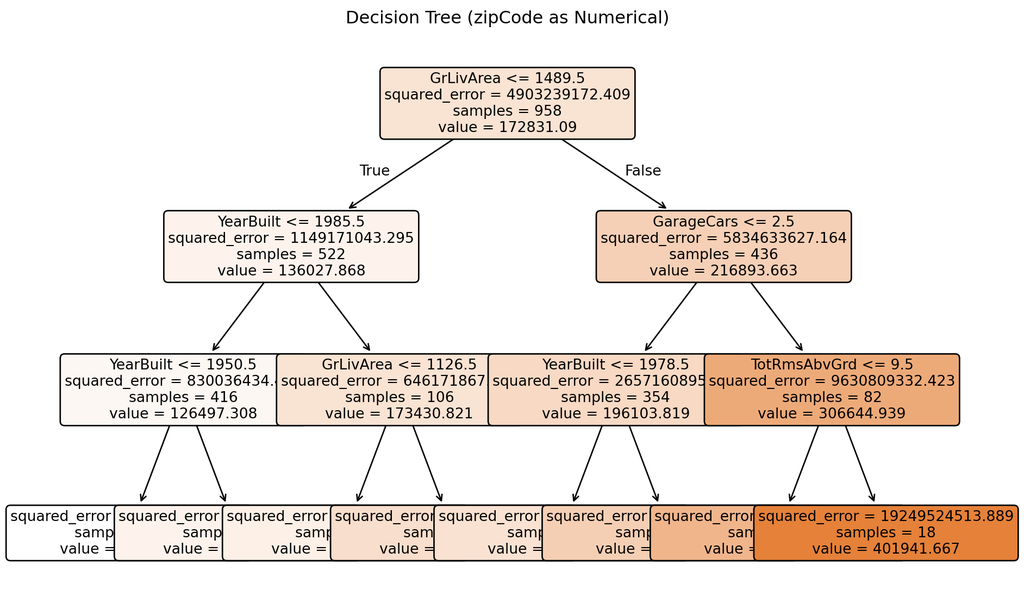

```python
# Visualize tree
plt.figure(figsize=(10, 6))
plot_tree(tree_model,
          feature_names=X_train.columns,
          filled=True,
          rounded=True,
          fontsize=10,
          max_depth=3)
plt.title("Decision Tree (zipCode as Numerical)")
plt.tight_layout()
plt.show()
```

## Feature Importance Analysis

### Python

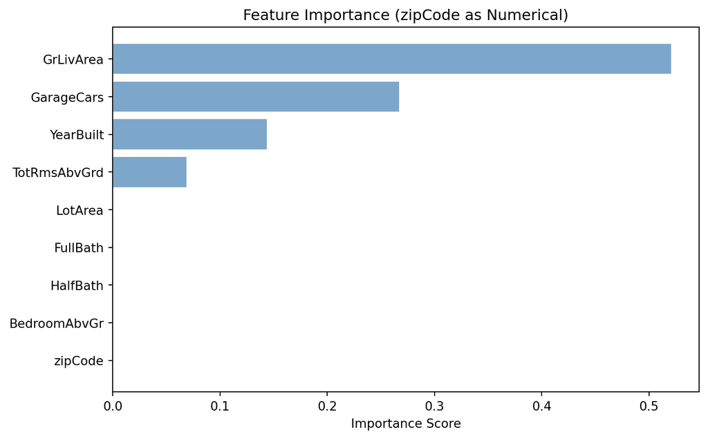

## Critical Analysis: The Encoding Problem

**Warning⚠️ The Problem Revealed**

**What to note:** Our decision tree treated `zipCode` as a numerical variable. This leads to zip code being unimportant. Not surprisingly, because there is no reason to believe allowing splits like “zipCode < 50012.5” should be beneficial for house price prediction. This false coding of a variable creates several problems:

1. **Potentially Meaningless Splits:** A zip code of 50013 is not “greater than” 50012 in any meaningful way for house prices
2. **False Importance:** The algorithm assigns importance to zipCode based on numerical splits rather than categorical distinctions OR the importance of zip code is completely missed as numerical ordering has no inherent relationship to house prices.
3. **Misleading Interpretations:** We might conclude zipCode is not important when our intuition tells us it should be important (listen to your intuition).

**The Real Issue:** Zip codes are categorical variables representing discrete geographic areas. The numerical values have no inherent order or magnitude relationship to house prices. These must be modelled as categorical variables.

## Proper Categorical Encoding: The Solution

Now let’s repeat the analysis with zipCode properly encoded as categorical variables to see the difference.

**Python Approach:** One-hot encode zipCode (create dummy variables for each zip code)

### Categorical Encoding Analysis

### Tree Visualization: Categorical zipCode

### Python

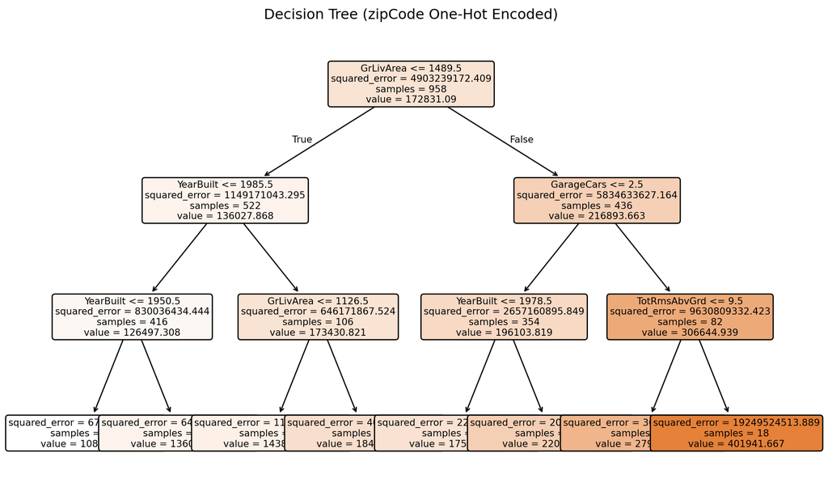

```python
# Visualize tree with one-hot encoded zipCode
plt.figure(figsize=(10, 6))
plot_tree(tree_model_cat,
          feature_names=X_train_cat.columns,
          filled=True,
          rounded=True,
          fontsize=8,
          max_depth=4)
plt.title("Decision Tree (zipCode One-Hot Encoded)")
plt.tight_layout()
plt.show()
```

### Feature Importance: Categorical zipCode

### Python

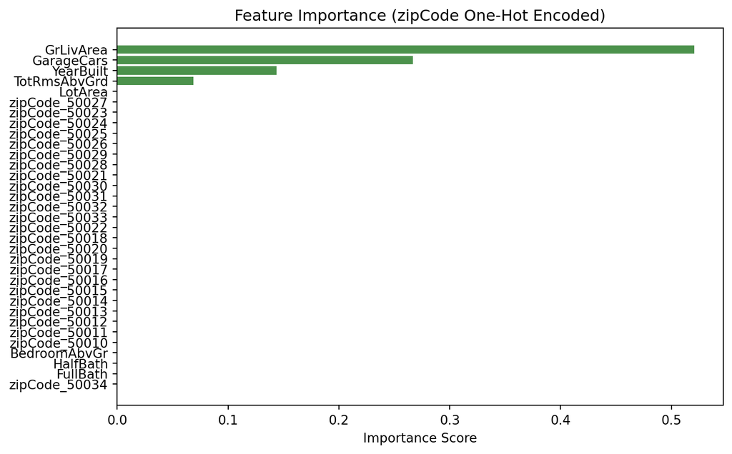

## Challenge Requirements 📋

### Minimum Requirements for Any Points on Challenge

1. **Create a GitHub Pages Site:** Use the starter repository (see Repository Setup section below) to begin with a working template. The repository includes all the analysis code and visualizations above.
2. **Add Discussion Narrative:** Add your answers to the two discussion questions below in the Discussion Questions section of the rendered HTML.
3. **GitHub Repository:** Use your forked repository (from the starter repository) named “decTreeChallenge” in your GitHub account.
4. **GitHub Pages Setup:** The repository should be made the source of your github pages:
   - Go to your repository settings (click the “Settings” tab in your GitHub repository)
   - Scroll down to the “Pages” section in the left sidebar
   - Under “Source”, select “Deploy from a branch”
   - Choose “main” branch and “/ (root)” folder
   - Click “Save”
   - Your site will be available at: `https://[your-username].github.io/decTreeChallenge/`
   - **Note:** It may take a few minutes for the site to become available after enabling Pages

## Getting Started: Repository Setup 🚀

**Important📁 Quick Start with Starter Repository**

**Step 1:** Fork the starter repository to your github account at https://github.com/flyaflya/decTreeChallenge.git

**Step 2:** Clone your fork locally using Cursor (or VS Code)

**Step 3:** You’re ready to start! The repository includes pre-loaded data and a working template with all the analysis above.

**Tip💡 Why Use the Starter Repository?**

**Benefits:**

- **Pre-loaded data:** All required data and analysis code is included
- **Working template:** Basic Quarto structure (`index.qmd`) is ready
- **No setup errors:** Avoid common data loading issues
- **Focus on analysis:** Spend time on the discussion questions, not data preparation

### Getting Started Tips

**Note🎯 Navy SEALs Motto**

> “Slow is Smooth and Smooth is Fast”

*Take your time to understand the decision tree mechanics, plan your approach carefully, and execute with precision. Rushing through this challenge will only lead to errors and confusion.*

**Warning💾 Important: Save Your Work Frequently!**

**Before you start:** Make sure to commit your work often using the Source Control panel in Cursor (Ctrl+Shift+G or Cmd+Shift+G). This prevents the AI from overwriting your progress and ensures you don’t lose your work.

**Commit after each major step:**

- After adding your discussion answers
- After rendering to HTML
- Before asking the AI for help with new code

**How to commit:**

1. Open Source Control panel (Ctrl+Shift+G)
2. Stage your changes (+ button)
3. Write a descriptive commit message
4. Click the checkmark to commit

*Remember: Frequent commits are your safety net!*

## Discussion Questions for Challenge

**Your Task:** Add thoughtful narrative answers to these questions in the Discussion Questions section of the rendered HTML site.

1. **Numerical vs Categorical Encoding:** There are two models in Python written above. For each language, the models differ by how zip code is modelled, either as a numerical variable or as a categorical variable. Given what you know about zip codes and real estate prices, how should zip code be modelled, numerically or categorically? Is zip code an ordinal or non-ordinal variable?

   **Answer.** **R’s `rpart`** works naturally with **factors**, so unordered categories are part of the data model; the tree search can respect **categorical structure** rather than treating codes as a continuous axis. **`sklearn.tree.DecisionTreeRegressor`** uses **CART** on a **numeric matrix**; you must **encode** categories yourself (e.g. one-hot), which **splits importance across many dummies** and changes the **tree shape** versus a single factor in R. Official documentation states:

   > “Able to handle both numerical and categorical data. **However, the scikit-learn implementation does not support categorical variables for now.**”

   — [Decision Trees — scikit-learn](https://scikit-learn.org/stable/modules/tree.html)

   > “scikit-learn uses an optimized version of the CART algorithm; **however, the scikit-learn implementation does not support categorical variables for now.**”

   — [same page](https://scikit-learn.org/stable/modules/tree.html)

   The [`DecisionTreeRegressor` API](https://scikit-learn.org/stable/modules/generated/sklearn.tree.DecisionTreeRegressor.html) describes training inputs as converted **internally to `dtype=np.float32`**, i.e. **numeric** features. For **direct** categorical handling without manual dummies, **R + `rpart`** is often more natural; **Python** is strong once you encode, and other libraries (below) add native categorical support.
3. **Are There Any Suggestions for Implementing Decision Trees in Python With Prioper Categorical Handling?** Please poke around the Internet (AI is not as helpful with new libraries) for suggestions on how to implement decision trees in Python with better (i.e. not one-hot encoding) categorical handling. Please provide a link to the source and a quote from the source. There is not right answer here, but please provide a thoughtful answer, I am curious to see what you find.

   **Answer.** One-hot encoding is a poor fit for decision trees with high-cardinality features like zip codes. As Damien Martin notes:

   > “Tree-based models, such as Decision Trees, Random Forests, and Boosted Trees, typically don’t perform well with one-hot encodings with lots of levels.”

   — [Are You Getting Burned By One-Hot Encoding?](https://kiwidamien.github.io/are-you-getting-burned-by-one-hot-encoding.html)

   The `category_encoders` library offers two better alternatives, both fully sklearn-compatible:

   **Target Encoding**

   Replaces each zip code with its mean target value, blended toward the global mean for rare categories. Per the scikit-learn docs:

   > “Each category is encoded based on a shrunk estimate of the average target values for observations belonging to the category.”

   — [sklearn TargetEncoder](https://scikit-learn.org/stable/modules/generated/sklearn.preprocessing.TargetEncoder.html)

   **Drawback:** Must be fit inside a `Pipeline` to prevent data leakage — if applied to the full dataset before splitting, target information bleeds into validation folds and inflates performance estimates.

   **Binary Encoding**

   Converts each zip to an integer then represents it in binary bits — “similar to onehot, but categories are stored as binary bitstrings.” 40,000 zip codes become just ~16 columns instead of 40,000, with no leakage risk and `inverse_transform` for reverse mapping.

   — [category_encoders BinaryEncoder](https://contrib.scikit-learn.org/category_encoders/binary.html)

   **Drawback:** The integer assigned to each zip before binarisation is arbitrary, so the resulting bit columns don’t group geographically or behaviourally similar zips together — the tree has to work harder to find meaningful patterns.

   Both are installed via: **pip install category_encoders**

## Grading Rubric 🎓

**Important📊 What You’re Really Being Graded On**

**This is an investigative report, not a coding exercise.** You’re analyzing decision tree models and reporting your findings like a professional analyst would. Think of this as a brief you’d write for a client or manager about why proper variable encoding matters in machine learning.

**What makes a great report:**

- **Clear narrative:** Tell the story of what you discovered about decision tree feature importance
- **Insightful analysis:** Focus on the most interesting differences between numerical and categorical encoding
- **Professional presentation:** Clean, readable, and engaging
- **Concise conclusions:** No AI babble or unnecessary technical jargon
- **Human insights:** Your interpretation of what the feature importance rankings actually mean (or don’t mean)
- **Documentation-based analysis:** For question 2, ground your analysis in actual library documentation

**What we’re looking for:** A compelling 1-2 minute read that demonstrates both the power of decision trees for interpretability and the critical importance of proper variable encoding. And a note on the current state of the art in decision tree implementation for categorical variables in Python.

### Questions to Answer for 75% Grade on Challenge

1. **Numerical vs Categorical Analysis:** Provide a clear, well-reasoned answer to question 1 about how zip codes should be modelled. Your answer should demonstrate understanding of why categorical variables need special treatment in decision trees.

### Questions to Answer for 95% - 100% Grade on Challenge

3. **Professional Presentation:** Your discussion answers should be written in a professional, engaging style that would be appropriate for a business audience learning about one-hot encoding and decision trees. Avoid technical jargon and focus on practical implications. Include a specific quote from the official documentation of `sklearn.tree.DecisionTreeRegressor` that supports your analysis.

## Submission Checklist ✅

**Minimum Requirements (Required for Any Points):**

- Forked starter repository from https://github.com/flyaflya/decTreeChallenge.git
- Cloned repository locally using Cursor (or VS Code)
- Added thoughtful narrative answers to both discussion questions
- Document rendered to HTML successfully
- HTML files uploaded to your forked repository
- GitHub Pages enabled and working
- Site accessible at `https://[your-username].github.io/decTreeChallenge/`

**75% Grade Requirements:**

- Clear, well-reasoned answer to question 1 about numerical vs categorical encoding

**85% Grade Requirements:**

- Thorough analysis of question 2 with investigation of official documentation

**95% Grade Requirements:**

- Professional presentation style appropriate for business audience.
- Specific quote from official documentation of `sklearn.tree.DecisionTreeRegressor` supporting your analysis

**100% Grade Requirements:**

- Note on the current state of the art in decision tree implementation for categorical variables in Python.

**Report Quality (Critical for Higher Grades):**

- Clear, engaging narrative that tells a story
- Focus on the most interesting findings about decision tree feature importance
- Professional writing style (no AI-generated fluff)
- Concise analysis that gets to the point
- Practical insights that would help a real data scientist
- Documentation-based analysis for technical questions